# trabajo1_idg_salas

2025-05-12

# Analisis espacial y bivariado del Censo2017: Adultos Mayores y Viviendas Precarias en la Provincia de Santiago

El presente análisis utiliza los datos del Censo 2017 para estudiar como se relacionan los factores de porcentaje de adultos mayores y el porcentaje de viviendas precarias (todo tipo de vivienda en mal estado)

# Objetivos

- Analizar la distribución de las personas mayores de 65 años en la provincia de santiago.
- Analizar la distribución de las personas que viven en casas con condiciones precarias en la misma provincia.
- Evaluar la relación entre ambos indicadores porcentuales.
- realizar mapas simples y bivariados para estos indicadores.
- Lograr Comparar visualmente la relacion entre las personas mayores y las viviendas precarias mediante los distintos mapas.

# Procesamiento de datos

en primer lugar, se instalan los paquetes necesarios y librerias necesarias para que el codigo pueda ejecutarse

```r
library(DBI)
library(RPostgres)
library(sf)
library(ggplot2)
library(cowplot)
library(biscale)
```

posteriormente, se configuran los parametros locales de conexion, para que desde R se apliquen las consultas sql y se conecte la base de datos

```r
# Configuración de parámetros de conexión
db_host     <- "localhost"
db_port     <- 5432
db_name     <- "Censo2017"
db_user     <- "postgres"
db_password <- "postgres"

# Conectar
con <- dbConnect(
  Postgres(),
  dbname = db_name,
  host = db_host,
  port = db_port,
  user = db_user,
  password = db_password
)
```

# Metodología

Preparación de los datos A través de sentencias SQL, se extrajo lainformación necesariadesde tablas desagregadas por persona y vivienda. Se calcularon dos indicadores clave a nivel comunal:

1. Preparación de los datos A través de sentencias SQL, se extrajo la información necesaria desde tablas desagregadas por persona y vivienda. Se calcularon dos indicadores clave a nivel comunal:

Porcentaje de personas mayores de 65 años, en relación al total de la población comunal.

Porcentaje de personas viviendo en viviendas precarias, considerando aquellas clasificadas como mediaguas, rucas o viviendas de material ligero.

Ambos indicadores fueron exportados y trabajados en R para su posterior análisis espacial. La tabla comunal fue vinculada con un archivo shapefile que contenía la geometría de las comunas de la Región Metropolitana.

luego se realizo una clasificación bivariada de los indicadores Una vez calculados, ambos indicadores fueron clasificados en tres niveles (bajo, medio y alto) según su distribución estadística.

finalmente se elaboro el mapa bivariado, el cual utilizo la informacion a nivel comunal de la provincia de santiago, de los dos indicadores porcentuales ya calculados en la consulta sql. Se construyó un mapa temático que permite visualizar simultáneamente los dos indicadores mediante una escala de colores combinada, donde cada tonalidad del mapa refleja una interacción específica entre el nivel de envejecimiento y el nivel de precariedad habitacional en cada comuna.

## calculo de indicadores porcentuales y formulacion matematica

Cálculo del % de Viviendas Precarias: Se calcula dividiendo el número de personas que viven en viviendas precarias (como mediaguas o viviendas con materiales no durables) entre la población total de la comuna. Fórmula: (Población en viviendas precarias / Población total) * 100

## codigos sql empleados

```r
sql_indicadores <- "
SELECT c.nom_comuna, c.codigo_comuna::double precision,
       COUNT(*) AS total_personas,
       COUNT(*) FILTER (WHERE p.p09 >65) AS total_adultos_mayores,
       ROUND(COUNT(*) FILTER (WHERE p.p09 >65) * 100.0 / COUNT(*),2) AS ptje_adultos_mayores
FROM personas AS p
JOIN hogares AS h ON p.hogar_ref_id = h.hogar_ref_id
JOIN viviendas AS v ON h.vivienda_ref_id = v.vivienda_ref_id
JOIN zonas AS z ON v.zonaloc_ref_id = z.zonaloc_ref_id
JOIN comunas AS c ON z.codigo_comuna = c.codigo_comuna
GROUP BY c.nom_comuna, c.codigo_comuna
ORDER BY ptje_adultos_mayores DESC;"

df_adultos_mayores <- dbGetQuery(con, sql_indicadores)
```

```r
sql_viviendas_precarias <- "
SELECT c.nom_comuna, c.codigo_comuna::double precision,
       COUNT(*) AS total_personas,
       COUNT(*) FILTER (WHERE v.p01 = 5 OR v.p03b = 6) AS total_personas_viv_precaria,
       ROUND(COUNT(*) FILTER (WHERE v.p01 = 5 OR v.p03b = 6) * 100.0 / COUNT(*), 2) AS ptje_viv_precarias
FROM personas AS p
JOIN hogares AS h ON p.hogar_ref_id = h.hogar_ref_id
JOIN viviendas AS v ON h.vivienda_ref_id = v.vivienda_ref_id
JOIN zonas AS z ON v.zonaloc_ref_id = z.zonaloc_ref_id
JOIN comunas AS c ON z.codigo_comuna = c.codigo_comuna
GROUP BY c.nom_comuna, c.codigo_comuna
ORDER BY ptje_viv_precarias DESC;"

df_viviendas_precarias <- dbGetQuery(con, sql_viviendas_precarias)
```

# RESULTADOS

Como primer vistazo, se añaden imagenes obtenidas directamente del resultado de las consultas sql en pgadmin 4. ### resultado consulta sql para indicador porcentual personas en viviendas precarias en la provincia de santiago

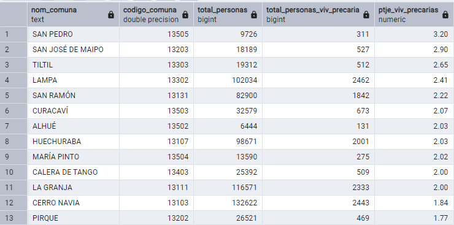

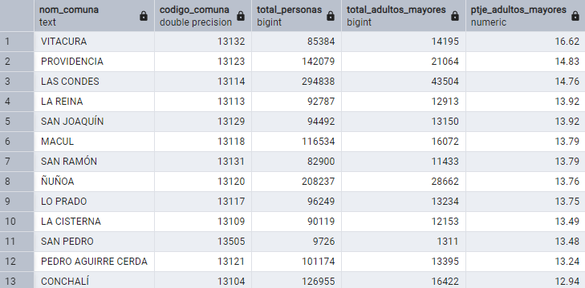

## Visualización Individual de Indicadores: Adultos Mayores y Viviendas Precarias

mediante mapas simples, se observa el comportamiento geografico de ambos indicadores en el territorio de la provincia de santiago

### mapa simple porcentaje de adultos mayores por comuna en la provincia de santiago

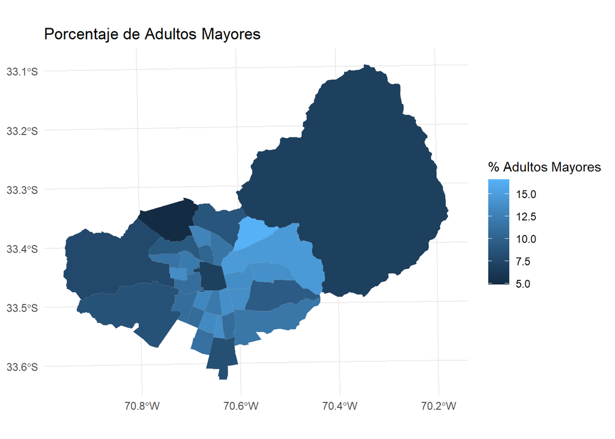

Zonas con mayor porcentaje de adultos mayores: Las comunas en el norte y el centro de la provincia, como Vitacura, Las Condes y La Reina, tienen un porcentaje más alto de adultos mayores. Esto puede estar relacionado con la mayor presencia de viviendas de tipo más alto o con características sociodemográficas que tienden a atraer a una población más envejecida.

Zonas con menor porcentaje de adultos mayores: Las áreas hacia el sur y suroeste, como algunas comunas de Maipú, La Florida, y Pudahuel, tienen un porcentaje más bajo. Esto puede deberse a una mayor presencia de población joven o de familias en crecimiento.

### mapa simple porcentaje de personas con viviendas precarias por comuna en la provincia de santiago

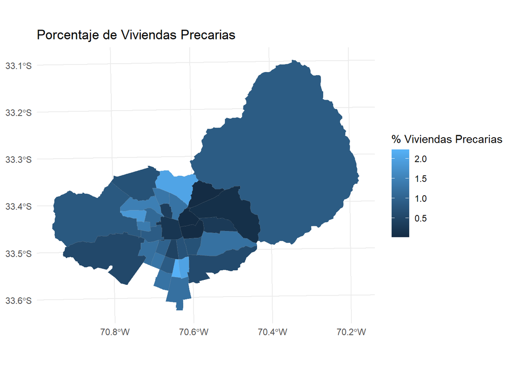

similar al caso del mapa anterior, se observan zonas con menor y mayor porcentaje de personas viviendo en casas en condiciones precarias, esto puede tener una explicacion sociodemografica y una relacion no lineal con el total de poblacion de adultos mayores, ya que hay sectores donde la poblacion de adultos mayores es alta, pero es bajo el porcentaje de viviendas en condiciones precarias, como por ejemplo lo son La Reina, Vitacura y Las Condes

## GRAFICO DISPERSION E INTERPRETACION DE LOS CUADRANTES

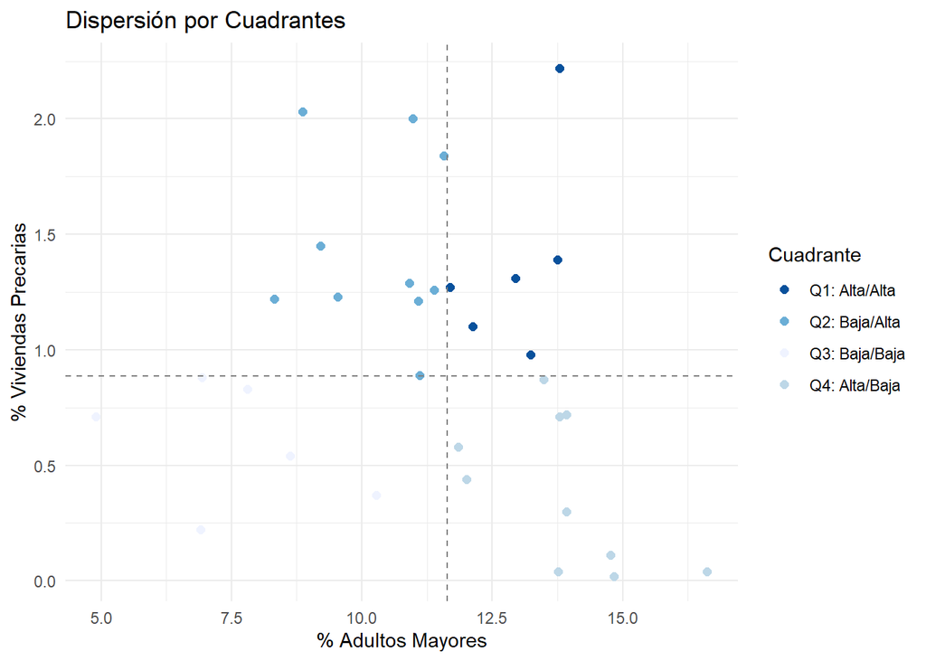

Existe cierta asociación entre la proporción de adultos mayores y viviendas precarias, aunque no es perfectamente lineal.

Algunas comunas están en situación más crítica (Q1): alta presencia de adultos mayores y también alta precariedad.

Las comunas en Q3 (baja/baja) podrían representar zonas con mejores condiciones sociales.

## MAPA BIVARIADO DE ADULTOS MAYORES VS VIVIENDAS PRECARIAS

se muestra a continuacion el resultado final de la creacion del mapa bivariado, donde a travez de la leyenda de 3x3, se analiza cada comuna y su porcentaje de adultos mayores y viviendas precarias La leyenda en la esquina inferior derecha indica cómo leer los colores: -Colores más oscuros en la esquina superior derecha: comunas con altos porcentajes en ambas variables. -Colores claros (esquina inferior izquierda): comunas con bajos porcentajes de adultos mayores y de precariedad. -Tonos lilas o rosados intensos (arriba a la izquierda): comunas con alta precariedad pero bajo % de adultos mayores. -Tonos celestes o turquesas (abajo a la derecha): comunas con alto % de adultos mayores pero baja precariedad.

Este tipo de análisis espacial puede ser muy útil en la planificación territorial y diseño de políticas públicas, especialmente para: Focalizar políticas habitacionales y de envejecimiento activo. Asignar recursos para infraestructura social, como centros de salud o programas de asistencia. Priorizar comunas en intervenciones urbanas integrales, combinando necesidades habitacionales y de atención al adulto mayor. El valor agregado del mapa bivariado radica en su capacidad para visualizar simultáneamente dos dimensiones sociales, facilitando una comprensión integrada del territorio. Esta herramienta permite a tomadores de decisiones, urbanistas y académicos detectar zonas críticas y patrones complejos que no serían evidentes con mapas univariados.

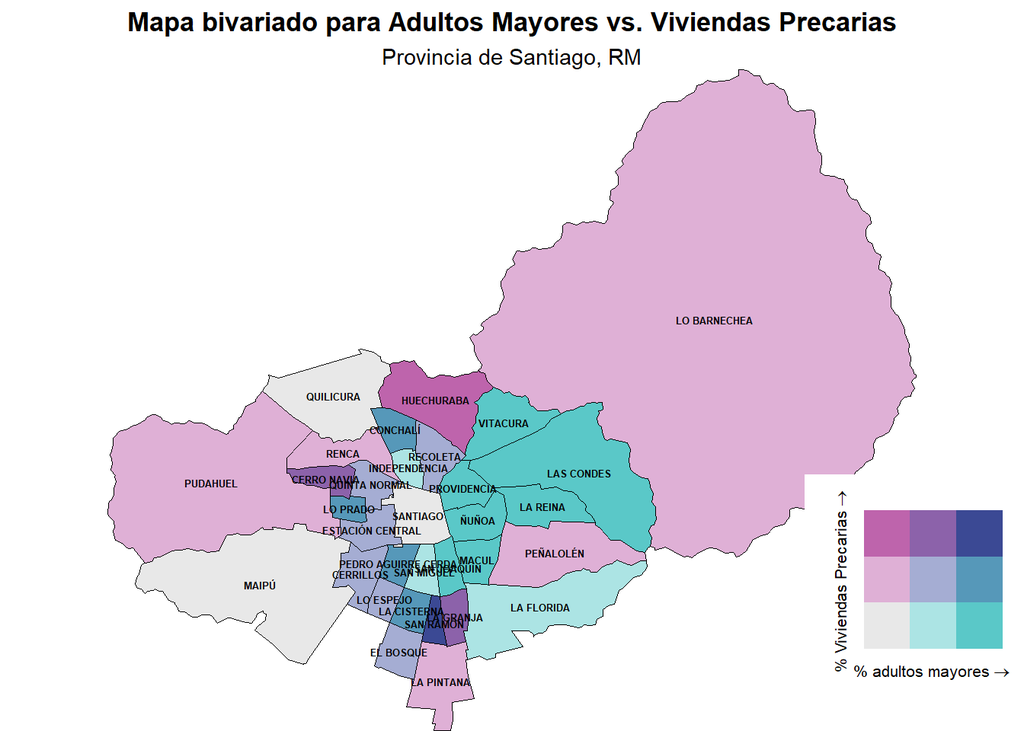

Cerro Navia, La Granja, Renca: Tonos más lilas (alta precariedad, pero menor proporción de adultos mayores).

Providencia, Ñuñoa, Vitacura: Colores más suaves y turquesa, lo que indica mayor presencia de adultos mayores, pero baja precariedad.

# CONCLUSION DEL TRABAJO

Patrones espaciales observados Adultos Mayores: Se observa que las comunas con mayor proporción de adultos mayores se concentran principalmente en la zona nororiente de la provincia (como Las Condes, Vitacura, La Reina). Estas zonas coinciden con áreas de mayor nivel socioeconómico y acceso a servicios de salud y vivienda consolidada. En contraste, las comunas del sur y poniente muestran proporciones más bajas, probablemente debido a una población más joven y dinámica.